# Introduction to Tidyverse

# Our work today

- Introduction
- Data manegement using dplyr
- Taming your data using readr
- Tidy data with tidyR
- Extra packages
- Intro to data visualization

If you prefer, the [R code](https://www.dropbox.com/s/4q7seukmuq82zn7/gsa_tidyverse_workshop.R?dl=0) for this presentation is available here. The datasets can be downloaded [here](https://www.dropbox.com/s/ipzwa2pnld8hknv/datasets.zip?dl=0).

## Setting up

After you download our material, please set your working directory to the folder where you saved the material. If you don’t like to set up working directories, Rstudio provide the rprojects tools, that basically connects everything for you from the beggining.

Just go on file>newproject>new_folder and save. Then, put everything in this folder, and you have everything you need to work.

# Introduction

The tidyverse is nothing more than a set of R packages built together to help us doing data science in R. The packages all share the same underlying design philosophy, grammar, and data structures. Therefore, if you learn one, the other packages come easier. The main packages of tidyverse are:

- **dplyr**: for data manipulation
- **ggplot2**: for data visualization
- **tidyr**: for modeling and data management
- **purrr**: for optimize your code and for functional programming
- **readr**: for open and organize the data

Today, we will mostly go over the beautiful world of data management using dplyr, readr, and tidyr. I strongly suggest you to add also ggplot2 to the list of things you should learn how to work with. I provide some extra material about ggplot2 here in the end of this file.

## How did I learn all this?

I have four main sources for the things we discuss here:

- Hadley Wickham’s book’s [here](http://r4ds.had.co.nz/) and [here](https://adv-r.hadley.nz/)
- [The Tidyverse website](https://www.tidyverse.org/)
- [Datacamp courses](https://www.datacamp.com)
- Eric Dunford’s GSA workshop last semester also inspired this material.

## Why should I use the tidyverse packages?

The main advantages:

- Easier to perform data management compared to base R
- Increase readability of your code
- Integrates well a series of useful package
- Advanced programmers do, therefore, very likely you get a code full of pipes and tidyverse packages in the future.

## Getting ready

#### Instalattion

```r
# Install from CRAN
install.packages("tidyverse")

# Or the development version from GitHub install.packages('devtools')

devtools::install_github("hadley/tidyverse")
```

```r
library(tidyverse)
library(conflicted)
```

#### Checking conflicts

```r
library(conflicted)
conflict_prefer("select", "dplyr")
conflict_prefer("filter", "dplyr")
```

## The pipe

The packages on tidyverse all rely on using the a shortcut function called `%>%` from the package `magritt`. The pipe is your friend, remember that.

The idea behind the pipe is quite simple: you pipe things within each other. The goal is to avoid how R reads codes from inside to outside.

The logic with pipe: first the object, then the functions, and then a sequence of functions. The operator makes it possible to easily chain a sequence of calculations

```r
# Example 1

# In base R

round(exp(diff(log(runif(100, 0, 1)))), 1)

# In pipe

runif(100, 0, 1) %>% log() %>% diff() %>% exp() %>% round(., 1)  # or round(1)
```

```r
# NOTE HERE: If is a tidyverse function, the data is always the first
# argument, therefore, one doesn't need to add the period. If it is not, one
# must add the period in the data argument

# data %>% function_tidyverse() %>% lm( y~x, data=. )

mtcars %>% lm(mpg ~ cyl, data = .) %>% coef()
```

```
(Intercept)         cyl
   37.88458    -2.87579
```

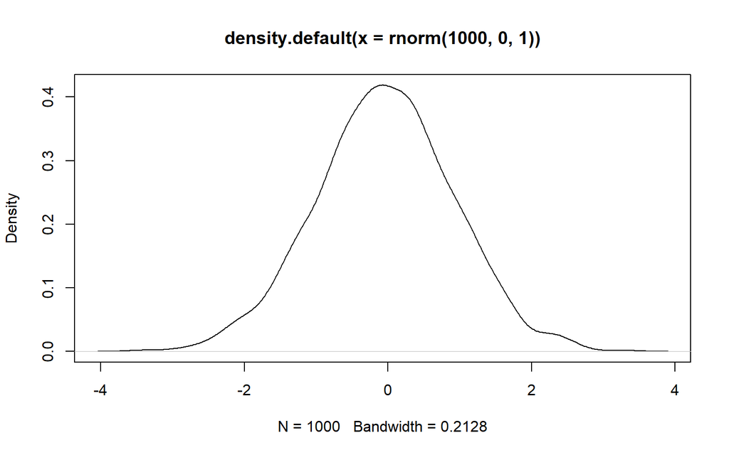

```r
# Example 2: Graph

plot(density(rnorm(1000, 0, 1)))
```

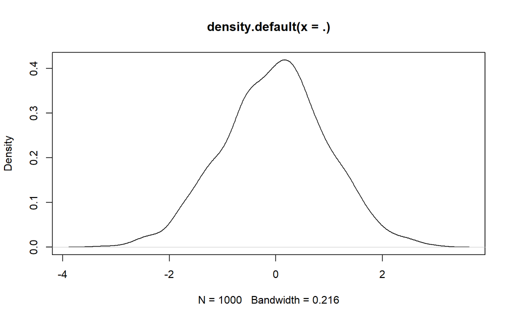

```r
# With pipe

rnorm(1000, 0, 1) %>% density() %>% plot()
```

# Dplyr for data management

The dplyr is the most famous tidyverse package. It deals with data management. It is my favorite package in the entire R world. I started working with dplyr two years after learning R, and it really made my life easier.

## Loading the data

We begin our work using the dataset `results`. The data has the results of all the international soccer matches from 1872 to 2018.

```r
d <- read_csv("results.csv")

# The first dplyr command: tibble data frame
d <- tbl_df(d)  # Nice to print

d
```

```
# A tibble: 39,669 x 9
   date       home_team away_team home_score away_score tournament city
   <date>     <chr>     <chr>          <int>      <int> <chr>      <chr>
 1 1872-11-30 Scotland  England            0          0 Friendly   Glas~
 2 1873-03-08 England   Scotland           4          2 Friendly   Lond~
 3 1874-03-07 Scotland  England            2          1 Friendly   Glas~
 4 1875-03-06 England   Scotland           2          2 Friendly   Lond~
 5 1876-03-04 Scotland  England            3          0 Friendly   Glas~
 6 1876-03-25 Scotland  Wales              4          0 Friendly   Glas~
 7 1877-03-03 England   Scotland           1          3 Friendly   Lond~
 8 1877-03-05 Wales     Scotland           0          2 Friendly   Wrex~
 9 1878-03-02 Scotland  England            7          2 Friendly   Glas~
10 1878-03-23 Scotland  Wales              9          0 Friendly   Glas~
# ... with 39,659 more rows, and 2 more variables: country <chr>,
#   neutral <lgl>
```

## Functions as verbs.

### The most useful

- **select()**: select columns
- **mutate()**: create new variables, change existing
- **filter()**: subset your data by some criterion
- **summarize()**: summarize your data in some way
- **group_by()**: group your data by a variable
- **slice()**: grab specific rows

### Some others

- **count()**: count your data
- **arrange()**: arrange your data by a column or variable
- **distinct()**: gather all distinct values of a variable
- **n_distinct()**: count how many distinct values you have (only works with summarize)
- **n()**: count how many observation you have for a subgroup
- **sample_n()**: Grab an N sample of your data
- **sampsle_frac()**: Grab a sample that is some fraction of your total data
- **ungroup()**: ungroup grouped data by a variable
- **glimpse()**: quickly preview the data
- **top_n()**: get the top N number of entries from a data frame
- **slice()**: grab specific rows

### Select : To select collumns

```r
# Base R


d_old <- d[, c("date", "away_score", "home_score")]


# Dplyr

d %>%
select(., date, home_team, away_team)
```

```
# A tibble: 39,669 x 3
   date       home_team away_team
   <date>     <chr>     <chr>
 1 1872-11-30 Scotland  England
 2 1873-03-08 England   Scotland
 3 1874-03-07 Scotland  England
 4 1875-03-06 England   Scotland
 5 1876-03-04 Scotland  England
 6 1876-03-25 Scotland  Wales
 7 1877-03-03 England   Scotland
 8 1877-03-05 Wales     Scotland
 9 1878-03-02 Scotland  England
10 1878-03-23 Scotland  Wales
# ... with 39,659 more rows
```

```r
# OR

d %>%
select(., 2:3, -5)
```

```
# A tibble: 39,669 x 2
   home_team away_team
   <chr>     <chr>
 1 Scotland  England
 2 England   Scotland
 3 Scotland  England
 4 England   Scotland
 5 Scotland  England
 6 Scotland  Wales
 7 England   Scotland
 8 Wales     Scotland
 9 Scotland  England
10 Scotland  Wales
# ... with 39,659 more rows
```

### Filter : To select rows

```r
# More than 1.000 favorites

d %>%
filter(home_team == "Brazil")
```

```
# A tibble: 552 x 9
   date       home_team away_team home_score away_score tournament city
   <date>     <chr>     <chr>          <int>      <int> <chr>      <chr>
 1 1916-07-08 Brazil    Chile              1          1 Copa Amér~ Buen~
 2 1916-07-12 Brazil    Uruguay            1          2 Copa Amér~ Buen~
 3 1917-10-12 Brazil    Chile              5          0 Copa Amér~ Mont~
 4 1919-05-11 Brazil    Chile              6          0 Copa Amér~ Rio ~
 5 1919-05-18 Brazil    Argentina          3          1 Copa Amér~ Rio ~
 6 1919-05-26 Brazil    Uruguay            2          2 Copa Amér~ Rio ~
 7 1919-05-29 Brazil    Uruguay            1          0 Copa Amér~ Rio ~
 8 1919-06-01 Brazil    Argentina          3          3 Friendly   Rio ~
 9 1920-09-18 Brazil    Uruguay            0          6 Copa Amér~ Viña~
10 1921-10-12 Brazil    Paraguay           3          0 Copa Amér~ Buen~
# ... with 542 more rows, and 2 more variables: country <chr>,
#   neutral <lgl>
```

```r
# Base R

d[d$home_team == "Brazil", ]
```

```
# A tibble: 552 x 9
   date       home_team away_team home_score away_score tournament city
   <date>     <chr>     <chr>          <int>      <int> <chr>      <chr>
 1 1916-07-08 Brazil    Chile              1          1 Copa Amér~ Buen~
 2 1916-07-12 Brazil    Uruguay            1          2 Copa Amér~ Buen~
 3 1917-10-12 Brazil    Chile              5          0 Copa Amér~ Mont~
 4 1919-05-11 Brazil    Chile              6          0 Copa Amér~ Rio ~
 5 1919-05-18 Brazil    Argentina          3          1 Copa Amér~ Rio ~
 6 1919-05-26 Brazil    Uruguay            2          2 Copa Amér~ Rio ~
 7 1919-05-29 Brazil    Uruguay            1          0 Copa Amér~ Rio ~
 8 1919-06-01 Brazil    Argentina          3          3 Friendly   Rio ~
 9 1920-09-18 Brazil    Uruguay            0          6 Copa Amér~ Viña~
10 1921-10-12 Brazil    Paraguay           3          0 Copa Amér~ Buen~
# ... with 542 more rows, and 2 more variables: country <chr>,
#   neutral <lgl>
```

```r
# Which one do you prefer???


# More than one condition
d %>%
filter(home_team == "Brazil", home_score - away_score > 0) %>%
select(date, away_team, tournament)
```

```
# A tibble: 395 x 3
   date       away_team tournament
   <date>     <chr>     <chr>
 1 1917-10-12 Chile     Copa América
 2 1919-05-11 Chile     Copa América
 3 1919-05-18 Argentina Copa América
 4 1919-05-29 Uruguay   Copa América
 5 1921-10-12 Paraguay  Copa América
 6 1922-10-15 Argentina Copa América
 7 1922-10-22 Paraguay  Copa América
 8 1922-10-22 Argentina Copa Roca
 9 1922-10-29 Paraguay  Friendly
10 1923-11-22 Paraguay  Friendly
# ... with 385 more rows
```

### Mutate: To create new variables

```r
library(conflicted)
conflict_prefer("select", "dplyr")
conflict_prefer("filter", "dplyr")

# Add the difference of goals, and a id for
# cases when the difference of gols is large,  and select what we did
# only for Brazil

d %>%

  mutate(dif = abs(away_score - home_score),

         goleada = ifelse(dif > 5, "Goleada", "Normal  Result")) %>%

    filter(home_team=="Brazil" | away_team=="Brazil",
                 goleada=="Goleada")
```

```
# A tibble: 41 x 11
   date       home_team away_team home_score away_score tournament city
   <date>     <chr>     <chr>          <int>      <int> <chr>      <chr>
 1 1919-05-11 Brazil    Chile              6          0 Copa Amér~ Rio ~
 2 1920-09-18 Brazil    Uruguay            0          6 Copa Amér~ Viña~
 3 1945-02-21 Brazil    Ecuador            9          2 Copa Amér~ Sant~
 4 1949-04-03 Brazil    Ecuador            9          1 Copa Amér~ Rio ~
 5 1949-04-10 Brazil    Bolivia           10          1 Copa Amér~ São ~
 6 1949-04-24 Brazil    Peru               7          1 Copa Amér~ Rio ~
 7 1949-05-11 Brazil    Paraguay           7          0 Copa Amér~ Rio ~
 8 1950-07-09 Brazil    Sweden             7          1 FIFA Worl~ Rio ~
 9 1953-03-01 Bolivia   Brazil             1          8 Copa Amér~ Lima
10 1956-03-13 Brazil    Costa Ri~          7          1 Pan Ameri~ Mexi~
# ... with 31 more rows, and 4 more variables: country <chr>,
#   neutral <lgl>, dif <int>, goleada <chr>
```

```r
# NOTE the ifelse is a extremely useful function

#ifelse(condition, TRUE, FALSE)

# Beautiful right?

# Base R
d_g <- d
d_g$dif <- abs(d$home_score - d$away_score)
d_g$goleada <- ifelse(d_g$dif >5, "Goleada", "NR")
d_g <- d_g[c(d$home_team=="Brazil" | d$away_team=="Brazil")  &
      d_g$goleada==1, c("home_team", "away_score", "goleada", "dif")]
```

### Arrange: To order de data by a particular variable

```r
# What was the largest difference in gols?

d %>%
mutate(dif = abs(away_score - home_score)) %>%
arrange(desc(dif)) %>%
slice(1)
```

```
# A tibble: 1 x 10
  date       home_team away_team home_score away_score tournament city
  <date>     <chr>     <chr>          <int>      <int> <chr>      <chr>
1 2001-04-11 Australia American~         31          0 FIFA Worl~ Coff~
# ... with 3 more variables: country <chr>, neutral <lgl>, dif <int>
```

### Slice: to slice your data by rows

```r
# The top 5 goleadas?

d %>%
mutate(dif = abs(away_score - home_score)) %>%
arrange(desc(dif)) %>%
slice(1:5)  # top_n(5) here would also do the trick
```

```
# A tibble: 5 x 10
  date       home_team away_team home_score away_score tournament city
  <date>     <chr>     <chr>          <int>      <int> <chr>      <chr>
1 2001-04-11 Australia American~         31          0 FIFA Worl~ Coff~
2 1979-08-30 Fiji      Kiribati          24          0 South Pac~ Naus~
3 2001-04-09 Australia Tonga             22          0 FIFA Worl~ Coff~
4 2005-03-11 Guam      Korea DPR          0         21 EAFF Cham~ Taip~
5 1987-12-15 American~ Papua Ne~          0         20 South Pac~ Noum~
# ... with 3 more variables: country <chr>, neutral <lgl>, dif <int>
```

### Group by + sumarize : forget about loops

- First: group by a particular variables
- Second: summarize the data with new statistics.

**Summarize**: Turn many rows into one.

Examples:

- min(x) - minimum value of vector x.
- max(x) - maximum value of vector x.
- mean(x) - mean value of vector x.
- median(x) - median value of vector x.
- quantile(x, p) - pth quantile of vector x.
- sd(x) - standard deviation of vector x.
- var(x) - variance of vector x.
- IQR(x) - Inter Quartile Range (IQR) of vector x.
- diff(range(x)) - total range of vector x.

```r
# Data on gols scored by home teams

d %>%
group_by(home_team) %>%
summarise(mean_home_gols = mean(home_score, na.rm = TRUE), sd_home_gols = sd(home_score),
    mean_home_gols_op = mean(away_score), count = n()) %>%
ungroup() %>%
top_n(., 10, wt = mean_home_gols)  # note here, it does
```

```
# A tibble: 10 x 5
   home_team       mean_home_gols sd_home_gols mean_home_gols_op count
   <chr>                    <dbl>        <dbl>             <dbl> <int>
 1 Cascadia                  4          NaN                0         1
 2 Gotland                   3.35         2.96             2.1      20
 3 Guersney                  3.25         2.51             1.04     24
 4 Kárpátalja                3.4          1.14             1.8       5
 5 Micronesia FS             3.5          4.95             9         2
 6 North Vietnam             3.6          3.13             1.8       5
 7 Northern Cyprus           3.70         3.97             0.609    23
 8 Sápmi                     4.12         5.75             1.5      16
 9 Somaliland                3.5          4.95             2.5       2
10 Western Sahara            3.33         1.53             2.33      3
```

```r
# not give you in order you can add arrange
```

Be careful, summarize is not the same as mutate. Check the example below, what is the difference:

```r
d %>%
group_by(home_team) %>%
mutate(mean_home_gols = mean(home_score, na.rm = TRUE), sd_home_gols = sd(home_score),
    mean_home_gols_op = mean(away_score), count = n()) %>% ungroup() %>%
select(home_team, mean_home_gols) %>%
top_n(., 10, wt = mean_home_gols)
```

```
# A tibble: 16 x 2
   home_team mean_home_gols
   <chr>              <dbl>
 1 Sápmi               4.12
 2 Sápmi               4.12
 3 Sápmi               4.12
 4 Sápmi               4.12
 5 Sápmi               4.12
 6 Sápmi               4.12
 7 Sápmi               4.12
 8 Sápmi               4.12
 9 Sápmi               4.12
10 Sápmi               4.12
11 Sápmi               4.12
12 Sápmi               4.12
13 Sápmi               4.12
14 Sápmi               4.12
15 Sápmi               4.12
16 Sápmi               4.12
```

You can go crazy, and get combinations using group_by

```r
# Proportion of victories of Brazil on different tournaments against each
# opponent.


d %>%
filter(home_team == "Brazil") %>%
mutate(dif = home_score - away_score, victory = ifelse(dif > 0, 1, 0)) %>%
group_by(away_team, tournament) %>%
summarise(mean_victory_brazil = mean(victory, na.rm = TRUE), number_games = n()) %>%

filter(away_team == "Argentina")
```

```
# A tibble: 7 x 4
# Groups:   away_team [1]
  away_team tournament                   mean_victory_brazil number_games
  <chr>     <chr>                                      <dbl>        <int>
1 Argentina Atlantic Cup                               1                1
2 Argentina Confederations Cup                         1                1
3 Argentina Copa América                               0.7             10
4 Argentina Copa Roca                                  0.538           13
5 Argentina FIFA World Cup                             0                1
6 Argentina FIFA World Cup qualification               1                3
7 Argentina Friendly                                   0.5             16
```

**CHECK IF YOU PREFER A FOR LOOP**

```r
d_b <- d[d$home_team == "Brazil", ]
d_b$dif <- d_b$home_score - d_b$away_score
d_b$victory <- ifelse(d_b$dif > 0, 1, 0)
j = 1
i = 1

# Create the container
out <- data_frame()

for (j in 1:unique(d_b$away_team)) {
    for (i in 1:unique(d_b$tournament)) {

        res <- d_b[d_b$away_team == unique(d_b$away_team)[j] & d_b$away_team ==
            unique(d_b$tournament)[i], "dif"]

    }
}

# I gave up after a few minutes trying
```

## Some other useful functions

#### Glimpse to see your data

```r
glimpse(d)
```

```
Observations: 39,669
Variables: 9
$ date       <date> 1872-11-30, 1873-03-08, 1874-03-07, 1875-03-06, 18...
$ home_team  <chr> "Scotland", "England", "Scotland", "England", "Scot...
$ away_team  <chr> "England", "Scotland", "England", "Scotland", "Engl...
$ home_score <int> 0, 4, 2, 2, 3, 4, 1, 0, 7, 9, 2, 5, 0, 5, 2, 5, 0, ...
$ away_score <int> 0, 2, 1, 2, 0, 0, 3, 2, 2, 0, 1, 4, 3, 4, 3, 1, 1, ...
$ tournament <chr> "Friendly", "Friendly", "Friendly", "Friendly", "Fr...
$ city       <chr> "Glasgow", "London", "Glasgow", "London", "Glasgow"...
$ country    <chr> "Scotland", "England", "Scotland", "England", "Scot...
$ neutral    <lgl> FALSE, FALSE, FALSE, FALSE, FALSE, FALSE, FALSE, FA...
```

### Count

```r
# Count here is a wrap for group_by and summarize n()

# Basically count the number of rows by group

d %>%
count(home_team, tournament) %>%
arrange(desc(n))
```

```
# A tibble: 1,710 x 3
   home_team   tournament     n
   <chr>       <chr>      <int>
 1 Germany     Friendly     289
 2 France      Friendly     286
 3 Mexico      Friendly     275
 4 Hungary     Friendly     272
 5 Sweden      Friendly     250
 6 Austria     Friendly     246
 7 Belgium     Friendly     242
 8 Poland      Friendly     241
 9 Netherlands Friendly     239
10 Switzerland Friendly     238
# ... with 1,700 more rows
```

#### Select Helper functions

- `starts_with()`: starts with a prefix
- `ends_with()`: ends with a prefix
- `contains()`: contains a literal string
- `matches()`: matches a regular expression
- `num_range()`: a numerical range like x01, x02, x03.
- `one_of()`: variables in character vector.
- `everything()`: all variables.

```r
# New Got Data:

new_got <- read_csv("battles.csv")
glimpse(new_got)
```

```
Observations: 38
Variables: 25
$ name               <chr> "Battle of the Golden Tooth", "Battle at th...
$ year               <int> 298, 298, 298, 298, 298, 298, 298, 299, 299...
$ battle_number      <int> 1, 2, 3, 4, 5, 6, 7, 8, 9, 10, 11, 12, 13, ...
$ attacker_king      <chr> "Joffrey/Tommen Baratheon", "Joffrey/Tommen...
$ defender_king      <chr> "Robb Stark", "Robb Stark", "Robb Stark", "...
$ attacker_1         <chr> "Lannister", "Lannister", "Lannister", "Sta...
$ attacker_2         <chr> NA, NA, NA, NA, "Tully", "Tully", NA, NA, N...
$ attacker_3         <chr> NA, NA, NA, NA, NA, NA, NA, NA, NA, NA, NA,...
$ attacker_4         <chr> NA, NA, NA, NA, NA, NA, NA, NA, NA, NA, NA,...
$ defender_1         <chr> "Tully", "Baratheon", "Tully", "Lannister",...
$ defender_2         <chr> NA, NA, NA, NA, NA, NA, NA, NA, NA, NA, NA,...
$ defender_3         <chr> NA, NA, NA, NA, NA, NA, NA, NA, NA, NA, NA,...
$ defender_4         <chr> NA, NA, NA, NA, NA, NA, NA, NA, NA, NA, NA,...
$ attacker_outcome   <chr> "win", "win", "win", "loss", "win", "win", ...
$ battle_type        <chr> "pitched battle", "ambush", "pitched battle...
$ major_death        <int> 1, 1, 0, 1, 1, 0, 0, 0, 0, 0, 0, 0, 0, 1, 1...
$ major_capture      <int> 0, 0, 1, 1, 1, 0, 0, 0, 0, 0, 0, 1, 1, 0, 1...
$ attacker_size      <int> 15000, NA, 15000, 18000, 1875, 6000, NA, NA...
$ defender_size      <int> 4000, 120, 10000, 20000, 6000, 12625, NA, N...
$ attacker_commander <chr> "Jaime Lannister", "Gregor Clegane", "Jaime...
$ defender_commander <chr> "Clement Piper, Vance", "Beric Dondarrion",...
$ summer             <int> 1, 1, 1, 1, 1, 1, 1, 1, 1, 1, 1, 1, 1, 1, 1...
$ location           <chr> "Golden Tooth", "Mummer's Ford", "Riverrun"...
$ region             <chr> "The Westerlands", "The Riverlands", "The R...
$ note               <chr> NA, NA, NA, NA, NA, NA, NA, NA, NA, "Greyjo...
```

```r
# Selecting

new_got %>%

  select(name, year, contains("king"),
          starts_with("battle")) %>%

  glimpse()
```

```
Observations: 38
Variables: 6
$ name          <chr> "Battle of the Golden Tooth", "Battle at the Mum...
$ year          <int> 298, 298, 298, 298, 298, 298, 298, 299, 299, 299...
$ attacker_king <chr> "Joffrey/Tommen Baratheon", "Joffrey/Tommen Bara...
$ defender_king <chr> "Robb Stark", "Robb Stark", "Robb Stark", "Joffr...
$ battle_number <int> 1, 2, 3, 4, 5, 6, 7, 8, 9, 10, 11, 12, 13, 14, 1...
$ battle_type   <chr> "pitched battle", "ambush", "pitched battle", "p...
```

```r
# Reordering

new_got %>%

  select(name, year, contains("king"),
          starts_with("battle"), everything()) %>%

  glimpse()
```

```
Observations: 38
Variables: 25
$ name               <chr> "Battle of the Golden Tooth", "Battle at th...
$ year               <int> 298, 298, 298, 298, 298, 298, 298, 299, 299...
$ attacker_king      <chr> "Joffrey/Tommen Baratheon", "Joffrey/Tommen...
$ defender_king      <chr> "Robb Stark", "Robb Stark", "Robb Stark", "...
$ battle_number      <int> 1, 2, 3, 4, 5, 6, 7, 8, 9, 10, 11, 12, 13, ...
$ battle_type        <chr> "pitched battle", "ambush", "pitched battle...
$ attacker_1         <chr> "Lannister", "Lannister", "Lannister", "Sta...
$ attacker_2         <chr> NA, NA, NA, NA, "Tully", "Tully", NA, NA, N...
$ attacker_3         <chr> NA, NA, NA, NA, NA, NA, NA, NA, NA, NA, NA,...
$ attacker_4         <chr> NA, NA, NA, NA, NA, NA, NA, NA, NA, NA, NA,...
$ defender_1         <chr> "Tully", "Baratheon", "Tully", "Lannister",...
$ defender_2         <chr> NA, NA, NA, NA, NA, NA, NA, NA, NA, NA, NA,...
$ defender_3         <chr> NA, NA, NA, NA, NA, NA, NA, NA, NA, NA, NA,...
$ defender_4         <chr> NA, NA, NA, NA, NA, NA, NA, NA, NA, NA, NA,...
$ attacker_outcome   <chr> "win", "win", "win", "loss", "win", "win", ...
$ major_death        <int> 1, 1, 0, 1, 1, 0, 0, 0, 0, 0, 0, 0, 0, 1, 1...
$ major_capture      <int> 0, 0, 1, 1, 1, 0, 0, 0, 0, 0, 0, 1, 1, 0, 1...
$ attacker_size      <int> 15000, NA, 15000, 18000, 1875, 6000, NA, NA...
$ defender_size      <int> 4000, 120, 10000, 20000, 6000, 12625, NA, N...
$ attacker_commander <chr> "Jaime Lannister", "Gregor Clegane", "Jaime...
$ defender_commander <chr> "Clement Piper, Vance", "Beric Dondarrion",...
$ summer             <int> 1, 1, 1, 1, 1, 1, 1, 1, 1, 1, 1, 1, 1, 1, 1...
$ location           <chr> "Golden Tooth", "Mummer's Ford", "Riverrun"...
$ region             <chr> "The Westerlands", "The Riverlands", "The R...
$ note               <chr> NA, NA, NA, NA, NA, NA, NA, NA, NA, "Greyjo...
```

```r
# Deleting some not relevant information
new_got %>%

  select(name, year, contains("king"),

          starts_with("battle"), everything(),

         -matches(c("1$|2$|3$|4$"))) %>%

  glimpse()
```

```
Observations: 38
Variables: 17
$ name               <chr> "Battle of the Golden Tooth", "Battle at th...
$ year               <int> 298, 298, 298, 298, 298, 298, 298, 299, 299...
$ attacker_king      <chr> "Joffrey/Tommen Baratheon", "Joffrey/Tommen...
$ defender_king      <chr> "Robb Stark", "Robb Stark", "Robb Stark", "...
$ battle_number      <int> 1, 2, 3, 4, 5, 6, 7, 8, 9, 10, 11, 12, 13, ...
$ battle_type        <chr> "pitched battle", "ambush", "pitched battle...
$ attacker_outcome   <chr> "win", "win", "win", "loss", "win", "win", ...
$ major_death        <int> 1, 1, 0, 1, 1, 0, 0, 0, 0, 0, 0, 0, 0, 1, 1...
$ major_capture      <int> 0, 0, 1, 1, 1, 0, 0, 0, 0, 0, 0, 1, 1, 0, 1...
$ attacker_size      <int> 15000, NA, 15000, 18000, 1875, 6000, NA, NA...
$ defender_size      <int> 4000, 120, 10000, 20000, 6000, 12625, NA, N...
$ attacker_commander <chr> "Jaime Lannister", "Gregor Clegane", "Jaime...
$ defender_commander <chr> "Clement Piper, Vance", "Beric Dondarrion",...
$ summer             <int> 1, 1, 1, 1, 1, 1, 1, 1, 1, 1, 1, 1, 1, 1, 1...
$ location           <chr> "Golden Tooth", "Mummer's Ford", "Riverrun"...
$ region             <chr> "The Westerlands", "The Riverlands", "The R...
$ note               <chr> NA, NA, NA, NA, NA, NA, NA, NA, NA, "Greyjo...
```

# Taming your data using readr

### Functions to import data

- `read_csv()`: comma separated (CSV) files
- `read_tsv()`: tab separated files
- `read_delim()`: general delimited files
- `read_fwf()`: fixed width files
- `read_table()`: tabular files where columns are separated by white-space.
- `read_log()`: web log files

### Functions to Tame your data: Parse Family

- `parse_logical`
- `parse_integer`
- `parse_factor`
- `parse_character`
- `parse_date`

You can you this function to fix and to identify problems on your variables.

```r
# Numeric
x <- c("1", "2", "3")
parse_number(x)
```

```
[1] 1 2 3
```

```r
# Character

names <- c("Tiago", "Augusto", "ventura", 3)
parse_character(names)
```

```
[1] "Tiago"   "Augusto" "ventura" "3"
```

```r
# Or date

parse_date("30 december 1988", format = "%d %B %y")
```

```
[1] NA
```

```r
parse_date("30 december 1988", format = "%d %B %Y")
```

```
[1] "1988-12-30"
```

```r
# More interesting: Return the error for you

x <- c("1", "2", "3", "tiago")
parse_number(x)
```

```
[1]  1  2  3 NA
attr(,"problems")
# A tibble: 1 x 4
    row   col expected actual
  <int> <int> <chr>    <chr>
1     4    NA a number tiago
```

```r
# Also

x <- c("10%", "$1000", "10 reais")
parse_number(x)
```

```
[1]   10 1000   10
```

You can use all the parse functions when opening your data just replacing parse_`*` by col_`*`

```r
got_cd <- read_csv("character-deaths.csv")
glimpse(got_cd)
```

```
Observations: 917
Variables: 13
$ name          <chr> "Addam Marbrand", "Aegon Frey (Jinglebell)", "Ae...
$ Allegiances   <chr> "Lannister", "None", "House Targaryen", "House G...
$ Death_y       <chr> "na", "299", NA, "300", NA, NA, "300", "300", NA...
$ Book_Death    <chr> NA, "3", "na", "5", NA, NA, "4", "5", NA, NA, "2...
$ Death_Chapter <chr> NA, "51", ".", "20", NA, NA, "35", NA, NA, NA, "...
$ Book_Intro    <chr> "56", "49", "5", "20", ",", NA, "21", "59", "11"...
$ Gender        <int> 1, 1, 1, 1, 1, 1, 1, 0, 1, 1, 1, 1, 1, 0, 1, 1, ...
$ Nobility      <int> 1, 1, 1, 1, 1, 1, 1, 1, 1, 0, 0, 0, 1, 0, 1, 0, ...
$ GoT           <int> 1, 0, 0, 0, 0, 0, 1, 1, 0, 0, 0, 1, 0, 0, 1, 1, ...
$ CoK           <int> 1, 0, 0, 0, 0, 1, 0, 1, 1, 0, 1, 1, 1, 1, 0, 0, ...
$ SoS           <int> 1, 1, 0, 0, 1, 1, 1, 1, 0, 1, 0, 1, 1, 0, 0, 0, ...
$ FfC           <int> 1, 0, 0, 0, 0, 0, 1, 0, 1, 0, 0, 0, 0, 0, 1, 0, ...
$ DwD           <int> 0, 0, 1, 1, 0, 0, 0, 1, 0, 0, 0, 1, 1, 0, 0, 0, ...
```

Some numerical variables come out as characters

```r
# Fix

got_cd <- read_csv("character-deaths.csv", col_types = cols(Death_y = col_number(),
    Book_Death = col_number(), Death_Chapter = col_number(), Book_Intro = col_number()))

glimpse(got_cd)
```

```
Observations: 917
Variables: 13
$ name          <chr> "Addam Marbrand", "Aegon Frey (Jinglebell)", "Ae...
$ Allegiances   <chr> "Lannister", "None", "House Targaryen", "House G...
$ Death_y       <dbl> NA, 299, NA, 300, NA, NA, 300, 300, NA, NA, 299,...
$ Book_Death    <dbl> NA, 3, NA, 5, NA, NA, 4, 5, NA, NA, 2, NA, 5, NA...
$ Death_Chapter <dbl> NA, 51, NA, 20, NA, NA, 35, NA, NA, NA, 56, NA, ...
$ Book_Intro    <dbl> 56, 49, 5, 20, NA, NA, 21, 59, 11, 0, 50, 54, 18...
$ Gender        <int> 1, 1, 1, 1, 1, 1, 1, 0, 1, 1, 1, 1, 1, 0, 1, 1, ...
$ Nobility      <int> 1, 1, 1, 1, 1, 1, 1, 1, 1, 0, 0, 0, 1, 0, 1, 0, ...
$ GoT           <int> 1, 0, 0, 0, 0, 0, 1, 1, 0, 0, 0, 1, 0, 0, 1, 1, ...
$ CoK           <int> 1, 0, 0, 0, 0, 1, 0, 1, 1, 0, 1, 1, 1, 1, 0, 0, ...
$ SoS           <int> 1, 1, 0, 0, 1, 1, 1, 1, 0, 1, 0, 1, 1, 0, 0, 0, ...
$ FfC           <int> 1, 0, 0, 0, 0, 0, 1, 0, 1, 0, 0, 0, 0, 0, 1, 0, ...
$ DwD           <int> 0, 0, 1, 1, 0, 0, 0, 1, 0, 0, 0, 1, 1, 0, 0, 0, ...
```

```r
# Check the problem

problems(got_cd)
```

```
# A tibble: 4 x 5
    row col           expected actual file
  <int> <chr>         <chr>    <chr>  <chr>
1     1 Death_y       a number na     'character-deaths.csv'
2     3 Book_Death    a number na     'character-deaths.csv'
3     3 Death_Chapter a number .      'character-deaths.csv'
4     5 Book_Intro    a number ,      'character-deaths.csv'
```

```r
# Proper Fix
got_cd <- read_csv("character-deaths.csv", col_types = cols(Death_y = col_number(),
    Book_Death = col_number(), Death_Chapter = col_number(), Book_Intro = col_number()),
    na = c("", "NA", "na", ".", ","))

got_cd
```

```
# A tibble: 917 x 13
   name  Allegiances Death_y Book_Death Death_Chapter Book_Intro Gender
   <chr> <chr>         <dbl>      <dbl>         <dbl>      <dbl>  <int>
 1 Adda~ Lannister        NA         NA            NA         56      1
 2 Aego~ None            299          3            51         49      1
 3 Aego~ House Targ~      NA         NA            NA          5      1
 4 Adra~ House Grey~     300          5            20         20      1
 5 Aemo~ Lannister        NA         NA            NA         NA      1
 6 Aemo~ Baratheon        NA         NA            NA         NA      1
 7 Aemo~ Night's Wa~     300          4            35         21      1
 8 Aeny~ None            300          5            NA         59      0
 9 Aero~ House Grey~      NA         NA            NA         11      1
10 Aeth~ Night's Wa~      NA         NA            NA          0      1
# ... with 907 more rows, and 6 more variables: Nobility <int>, GoT <int>,
#   CoK <int>, SoS <int>, FfC <int>, DwD <int>
```

# Tidy Data using tidyR

Tidy data is a fancy name for data in the long format. A data is tidy when:

1. Each variable must have its own column.
2. Each observation must have its own row.

### Untidy data

| date | home_team | away_team | Atlantic Cup | Brazil Independence Cup | Confederations Cup | Copa América | Copa Bernardo O’Higgins | Copa Oswaldo Cruz | Copa Rio Branco | Copa Roca | FIFA World Cup | FIFA World Cup qualification | Friendly | Gold Cup | Mundialito | Pan American Championship | USA Cup |
| --- | --- | --- | --- | --- | --- | --- | --- | --- | --- | --- | --- | --- | --- | --- | --- | --- | --- |
| 1916-07-08 | Brazil | Chile | NA | NA | NA | 0 | NA | NA | NA | NA | NA | NA | NA | NA | NA | NA | NA |
| 1916-07-12 | Brazil | Uruguay | NA | NA | NA | -1 | NA | NA | NA | NA | NA | NA | NA | NA | NA | NA | NA |
| 1917-10-12 | Brazil | Chile | NA | NA | NA | 5 | NA | NA | NA | NA | NA | NA | NA | NA | NA | NA | NA |
| 1919-05-11 | Brazil | Chile | NA | NA | NA | 6 | NA | NA | NA | NA | NA | NA | NA | NA | NA | NA | NA |
| 1919-05-18 | Brazil | Argentina | NA | NA | NA | 2 | NA | NA | NA | NA | NA | NA | NA | NA | NA | NA | NA |
| 1919-05-26 | Brazil | Uruguay | NA | NA | NA | 0 | NA | NA | NA | NA | NA | NA | NA | NA | NA | NA | NA |
| 1919-05-29 | Brazil | Uruguay | NA | NA | NA | 1 | NA | NA | NA | NA | NA | NA | NA | NA | NA | NA | NA |
| 1919-06-01 | Brazil | Argentina | NA | NA | NA | NA | NA | NA | NA | NA | NA | NA | 0 | NA | NA | NA | NA |
| 1920-09-18 | Brazil | Uruguay | NA | NA | NA | -6 | NA | NA | NA | NA | NA | NA | NA | NA | NA | NA | NA |
| 1921-10-12 | Brazil | Paraguay | NA | NA | NA | 3 | NA | NA | NA | NA | NA | NA | NA | NA | NA | NA | NA |
| 1921-10-23 | Brazil | Uruguay | NA | NA | NA | -1 | NA | NA | NA | NA | NA | NA | NA | NA | NA | NA | NA |
| 1922-09-17 | Brazil | Chile | NA | NA | NA | 0 | NA | NA | NA | NA | NA | NA | NA | NA | NA | NA | NA |
| 1922-09-24 | Brazil | Paraguay | NA | NA | NA | 0 | NA | NA | NA | NA | NA | NA | NA | NA | NA | NA | NA |
| 1922-10-01 | Brazil | Uruguay | NA | NA | NA | 0 | NA | NA | NA | NA | NA | NA | NA | NA | NA | NA | NA |
| 1922-10-15 | Brazil | Argentina | NA | NA | NA | 2 | NA | NA | NA | NA | NA | NA | NA | NA | NA | NA | NA |
| 1922-10-22 | Brazil | Argentina | NA | NA | NA | NA | NA | NA | NA | 1 | NA | NA | NA | NA | NA | NA | NA |
| 1922-10-22 | Brazil | Paraguay | NA | NA | NA | 3 | NA | NA | NA | NA | NA | NA | NA | NA | NA | NA | NA |
| 1922-10-29 | Brazil | Paraguay | NA | NA | NA | NA | NA | NA | NA | NA | NA | NA | 2 | NA | NA | NA | NA |
| 1923-11-11 | Brazil | Paraguay | NA | NA | NA | -1 | NA | NA | NA | NA | NA | NA | NA | NA | NA | NA | NA |
| 1923-11-22 | Brazil | Paraguay | NA | NA | NA | NA | NA | NA | NA | NA | NA | NA | 2 | NA | NA | NA | NA |
| 1925-12-06 | Brazil | Paraguay | NA | NA | NA | 3 | NA | NA | NA | NA | NA | NA | NA | NA | NA | NA | NA |
| 1925-12-17 | Brazil | Paraguay | NA | NA | NA | 2 | NA | NA | NA | NA | NA | NA | NA | NA | NA | NA | NA |
| 1930-07-14 | Brazil | Yugoslavia | NA | NA | NA | NA | NA | NA | NA | NA | -1 | NA | NA | NA | NA | NA | NA |
| 1930-08-01 | Brazil | France | NA | NA | NA | NA | NA | NA | NA | NA | NA | NA | 1 | NA | NA | NA | NA |
| 1930-08-10 | Brazil | Yugoslavia | NA | NA | NA | NA | NA | NA | NA | NA | NA | NA | 3 | NA | NA | NA | NA |
| 1930-08-17 | Brazil | USA | NA | NA | NA | NA | NA | NA | NA | NA | NA | NA | 1 | NA | NA | NA | NA |
| 1931-09-06 | Brazil | Uruguay | NA | NA | NA | NA | NA | NA | 2 | NA | NA | NA | NA | NA | NA | NA | NA |
| 1934-05-27 | Brazil | Spain | NA | NA | NA | NA | NA | NA | NA | NA | -2 | NA | NA | NA | NA | NA | NA |
| 1936-12-27 | Brazil | Peru | NA | NA | NA | 1 | NA | NA | NA | NA | NA | NA | NA | NA | NA | NA | NA |
| 1937-01-03 | Brazil | Chile | NA | NA | NA | 2 | NA | NA | NA | NA | NA | NA | NA | NA | NA | NA | NA |

[output cut: 522 more lines]

### Tidy Data

| date | home_team | away_team | home_score | away_score | tournament | city | country | neutral |
| --- | --- | --- | --- | --- | --- | --- | --- | --- |
| 1872-11-30 | Scotland | England | 0 | 0 | Friendly | Glasgow | Scotland | FALSE |
| 1873-03-08 | England | Scotland | 4 | 2 | Friendly | London | England | FALSE |
| 1874-03-07 | Scotland | England | 2 | 1 | Friendly | Glasgow | Scotland | FALSE |
| 1875-03-06 | England | Scotland | 2 | 2 | Friendly | London | England | FALSE |
| 1876-03-04 | Scotland | England | 3 | 0 | Friendly | Glasgow | Scotland | FALSE |
| 1876-03-25 | Scotland | Wales | 4 | 0 | Friendly | Glasgow | Scotland | FALSE |
| 1877-03-03 | England | Scotland | 1 | 3 | Friendly | London | England | FALSE |
| 1877-03-05 | Wales | Scotland | 0 | 2 | Friendly | Wrexham | Wales | FALSE |
| 1878-03-02 | Scotland | England | 7 | 2 | Friendly | Glasgow | Scotland | FALSE |
| 1878-03-23 | Scotland | Wales | 9 | 0 | Friendly | Glasgow | Scotland | FALSE |

### Gather (tidyR)

It collapses multiple columns into two columns. When people say reshaping your data, it is the same of tidying using gather.

`gather(data, key="my_key", value="values_of_each_col", ...="col_you_have_want_to_distribute")`

```r
# Gathering our data together again.

d_untidy %>% gather(key = "key", value = "value", 4:18)
```

```
# A tibble: 8,280 x 5
   date       home_team away_team key          value
   <date>     <chr>     <chr>     <chr>        <int>
 1 1916-07-08 Brazil    Chile     Atlantic Cup    NA
 2 1916-07-12 Brazil    Uruguay   Atlantic Cup    NA
 3 1917-10-12 Brazil    Chile     Atlantic Cup    NA
 4 1919-05-11 Brazil    Chile     Atlantic Cup    NA
 5 1919-05-18 Brazil    Argentina Atlantic Cup    NA
 6 1919-05-26 Brazil    Uruguay   Atlantic Cup    NA
 7 1919-05-29 Brazil    Uruguay   Atlantic Cup    NA
 8 1919-06-01 Brazil    Argentina Atlantic Cup    NA
 9 1920-09-18 Brazil    Uruguay   Atlantic Cup    NA
10 1921-10-12 Brazil    Paraguay  Atlantic Cup    NA
# ... with 8,270 more rows
```

```r
# Fixing the Na

d_untidy %>% gather(key = "key", value = "value", 4:18, na.rm = TRUE)
```

```
# A tibble: 552 x 5
   date       home_team away_team      key                     value
 * <date>     <chr>     <chr>          <chr>                   <int>
 1 1956-06-24 Brazil    Uruguay        Atlantic Cup                2
 2 1960-07-12 Brazil    Argentina      Atlantic Cup                4
 3 1972-06-28 Brazil    Czechoslovakia Brazil Independence Cup     0
 4 1972-07-02 Brazil    Yugoslavia     Brazil Independence Cup     3
 5 1972-07-05 Brazil    Scotland       Brazil Independence Cup     1
 6 1972-07-09 Brazil    Portugal       Brazil Independence Cup     1
 7 1997-12-16 Brazil    Mexico         Confederations Cup          1
 8 1997-12-19 Brazil    Czech Republic Confederations Cup          2
 9 1997-12-21 Brazil    Australia      Confederations Cup          6
10 1999-07-24 Brazil    Germany        Confederations Cup          4
# ... with 542 more rows
```

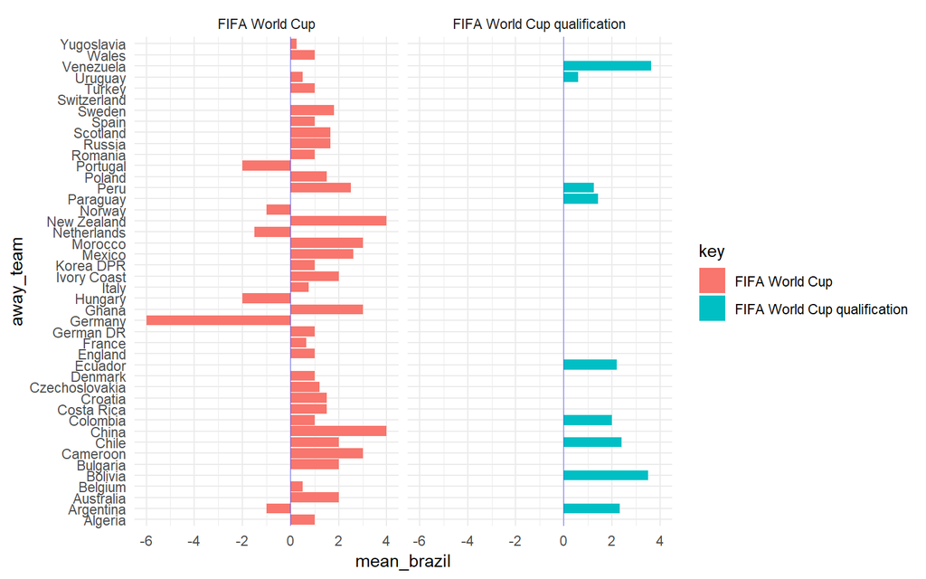

```r
# Graphing

d_untidy %>%
select(1:3, contains("FIFA")) %>% gather(key = "key", value = "value", 4:5,
    factor_key = TRUE, na.rm = TRUE) %>%
group_by(key, away_team) %>%
summarise(mean_brazil = mean(value)) %>%
ggplot(., aes(y = mean_brazil, x = away_team, group = away_team, fill = key)) +

geom_col(position = "dodge") +
coord_flip() +
geom_hline(yintercept = 0, alpha = 0.3, color = "blue") +
facet_wrap(~key) +
theme_minimal()
```

### Separate

`separate(data, col="one_you_want_to_separate", into="division", sep="regular_expression")`

```r
d_untidy %>%
separate(col = date, into = c("year", "month", "day"))
```

```
# A tibble: 552 x 20
   year  month day   home_team away_team `Atlantic Cup` `Brazil Indepen~
   <chr> <chr> <chr> <chr>     <chr>              <int>            <int>
 1 1916  07    08    Brazil    Chile                 NA               NA
 2 1916  07    12    Brazil    Uruguay               NA               NA
 3 1917  10    12    Brazil    Chile                 NA               NA
 4 1919  05    11    Brazil    Chile                 NA               NA
 5 1919  05    18    Brazil    Argentina             NA               NA
 6 1919  05    26    Brazil    Uruguay               NA               NA
 7 1919  05    29    Brazil    Uruguay               NA               NA
 8 1919  06    01    Brazil    Argentina             NA               NA
 9 1920  09    18    Brazil    Uruguay               NA               NA
10 1921  10    12    Brazil    Paraguay              NA               NA
# ... with 542 more rows, and 13 more variables: `Confederations
#   Cup` <int>, `Copa América` <int>, `Copa Bernardo O'Higgins` <int>,
#   `Copa Oswaldo Cruz` <int>, `Copa Rio Branco` <int>, `Copa Roca` <int>,
#   `FIFA World Cup` <int>, `FIFA World Cup qualification` <int>,
#   Friendly <int>, `Gold Cup` <int>, Mundialito <int>, `Pan American
#   Championship` <int>, `USA Cup` <int>
```

```r
# Here, the default is to separate any sequence of non-alphanumeric values.

# Unite() does the opposite
```

### Spread

```r
# Tournaments Oppenents on the column

d %>% select(1:5, tournament) %>%
filter(home_team == "Brazil") %>%
mutate(diff = home_score - away_score) %>%
spread(key = tournament, value = diff) %>%
dplyr::select(-contains("score"))
```

```
# A tibble: 552 x 18
   date       home_team away_team `Atlantic Cup` `Brazil Indepen~
   <date>     <chr>     <chr>              <int>            <int>
 1 1916-07-08 Brazil    Chile                 NA               NA
 2 1916-07-12 Brazil    Uruguay               NA               NA
 3 1917-10-12 Brazil    Chile                 NA               NA
 4 1919-05-11 Brazil    Chile                 NA               NA
 5 1919-05-18 Brazil    Argentina             NA               NA
 6 1919-05-26 Brazil    Uruguay               NA               NA
 7 1919-05-29 Brazil    Uruguay               NA               NA
 8 1919-06-01 Brazil    Argentina             NA               NA
 9 1920-09-18 Brazil    Uruguay               NA               NA
10 1921-10-12 Brazil    Paraguay              NA               NA
# ... with 542 more rows, and 13 more variables: `Confederations
#   Cup` <int>, `Copa América` <int>, `Copa Bernardo O'Higgins` <int>,
#   `Copa Oswaldo Cruz` <int>, `Copa Rio Branco` <int>, `Copa Roca` <int>,
#   `FIFA World Cup` <int>, `FIFA World Cup qualification` <int>,
#   Friendly <int>, `Gold Cup` <int>, Mundialito <int>, `Pan American
#   Championship` <int>, `USA Cup` <int>
```

# Extra functions and packages on data manipulation

- `case_when()`: replacement for if else.
- `fct_relevel()` : to work with factors.
- `ludibrate` package for working with dates.
- `stringr` package to work with strings.

### Quick example of lubridate

```r
library(lubridate)

ymd("2013-september, 20")
```

```
[1] "2013-09-20"
```

```r
mdy("dec 30 1988")
```

```
[1] "1988-12-30"
```

```r
# With mutate: Number of goals per year


d_time <- d %>%

  mutate(year= year(date),
         month= month(date)) %>%

  mutate(interval = interval(date,today()),
         time_span= as.period(interval),
         in_months = interval / months(6)) %>% # per semester %>%

  group_by(year) %>%

  summarize(total_gols= sum(home_score + away_score)) %>%


  ggplot(., aes(y=total_gols, x=year)) +

  geom_point( color="pink") +

  geom_smooth(method="loess",span=.1,colour="blue") +

  labs(title="",
          x="Years", y="Number of gols") +

  theme_minimal()
```

### Quick example stringR

```r
library(conflicted)
conflict_prefer("filter", "dplyr")


# everything starts with str
got <- read_csv("battles.csv")

got_red <- got %>%
mutate(attacker_king = str_to_lower(attacker_king), stark = str_detect(attacker_king,
    "stark"), attacker_king = str_replace_all(attacker_king, "joffrey/tommen baratheon",
    "cersey lannister"), attacker_no_endspace = str_trim(attacker_king)) %>%

select(attacker_king, stark, major_death) %>%
bind_cols(., as_data_frame(str_split(.$attacker_king, pattern = fixed(" "),
    simplify = TRUE, n = 2)))

print(got_red)
```

```
# A tibble: 38 x 5
   attacker_king       stark major_death V1          V2
   <chr>               <lgl>       <int> <chr>       <chr>
 1 cersey lannister    FALSE           1 cersey      lannister
 2 cersey lannister    FALSE           1 cersey      lannister
 3 cersey lannister    FALSE           0 cersey      lannister
 4 robb stark          TRUE            1 robb        stark
 5 robb stark          TRUE            1 robb        stark
 6 robb stark          TRUE            0 robb        stark
 7 cersey lannister    FALSE           0 cersey      lannister
 8 balon/euron greyjoy FALSE           0 balon/euron greyjoy
 9 balon/euron greyjoy FALSE           0 balon/euron greyjoy
10 balon/euron greyjoy FALSE           0 balon/euron greyjoy
# ... with 28 more rows
```

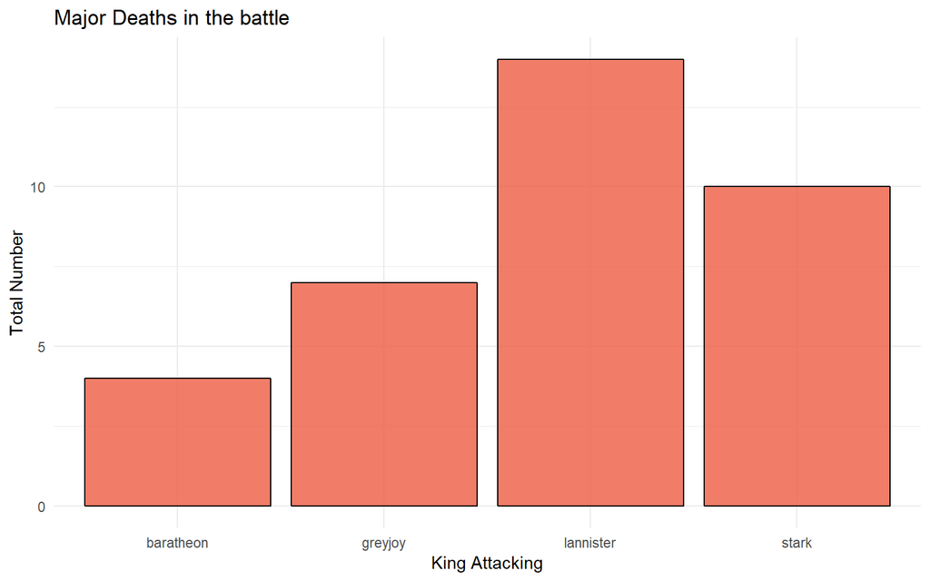

```r
got_red %>%
na.omit() %>%
count(V2) %>%
ggplot(., aes(y = n, x = V2)) +
geom_col(fill = "tomato2", alpha = 0.8, color = "black") + theme_minimal() +

labs(title = "Major Deaths in the battle", y = "Total Number", x = "King Attacking")
```

# Extra Material

### Data Visualization on ggplot2

ggplot2 is a package from tidyverse. It shares the logic of the tidyverse using simple, intuitive functions and working well with pipes. It produces amazing graphs, and allows one to easily combine different features, layers, and information on the same graph.

See this [link](http://r-statistics.co/Top50-Ggplot2-Visualizations-MasterList-R-Code.html) to get some examples of ggplot graphs

### Two importants principles

```
   - Graphics are distinct layers of elements

      - Meaninful plots work mapping the aesthetics.
```

### Elements

```
   - Data

      - Aesthetics : scales

      - Geometries : visual elements
```

### Basic workflow

GGplot work on layers. The grammar works pilling up different layers.

#### First layer: data

#### Second layer: Aesthetics.

- What is your x?
- what is your y?
- Are you groupping on something
- Here you add variations on the plot (color, fill, transparency, shape)

#### Third Layer: Geometries

- `geom_histogram()` : histogram
- `geom_bar()` : bar plot
- `geom_line()` : line plot
- `geom_point()` : scatter plot
- `geom_boxplot()` : box plot
- `geom_density()` : density plot
- `geom_dotplot()` : dot plot
- `geom_violin()` : violin plot

#### Other Layers: Customization

- `theme_bw()` : black and white
- `theme_classic()` : old school no grids
- `theme_dark()` : dark theme
- `theme_minimal()` : minimal theme
- `theme_void()` : no theme
- `scale_*aes*_()` : To change the aesthetichs
- `labs ()`: for labels
- `xlim()` or `ylim()`: for limits

## Example: Electoral data in Brazil

## geom_point

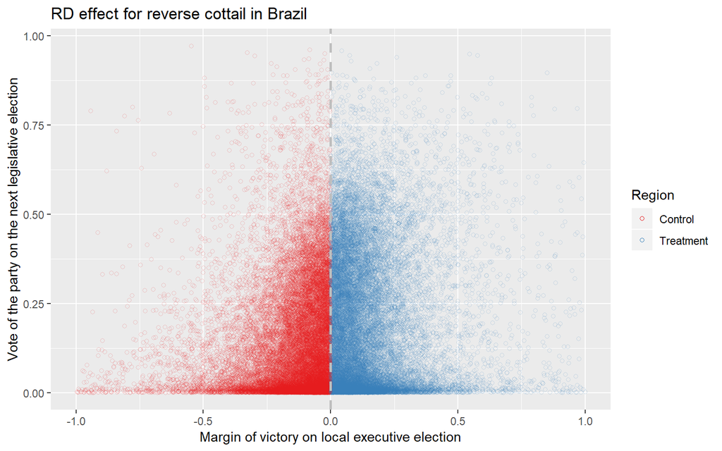

```r
load("data-venturareplication.rda")

df <- df %>% mutate(treat = ifelse(rankvote == 1, 1, 0)) %>% dplyr::filter(vote_margin_share !=
    1, vote_margin_share != -1)


ggplot(df, aes(x = vote_margin_share, y = vs_party, color = factor(treat, labels = c("Control",
    "Treatment")))) + geom_point(shape = 21, alpha = 0.2) +
scale_color_brewer(NULL, type = "qual", palette = 6) +
guides(colour = guide_legend("Region", override.aes = list(alpha = 1))) +
geom_vline(aes(xintercept = 0), color = "grey", size = 1, linetype = "dashed") +


labs(x = "Margin of victory on local executive election", y = "Vote of the party on the next legislative election",
    title = "RD effect for reverse cottail in Brazil")
```

## Geom_smooth

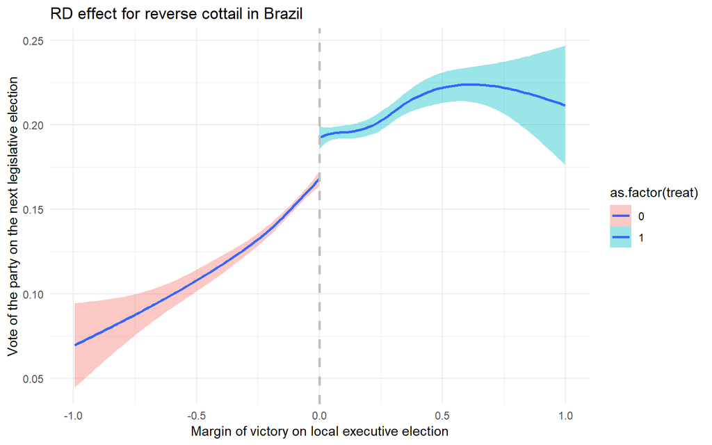

```r
ggplot(df, aes(x = vote_margin_share, y = vs_party, group = as.factor(treat),
    fill = as.factor(treat))) + geom_smooth() + geom_vline(aes(xintercept = 0),
    color = "grey", size = 1, linetype = "dashed") + labs(x = "Margin of victory on local executive election",
    y = "Vote of the party on the next legislative election", title = "RD effect for reverse cottail in Brazil") +
    theme_minimal()
```

## Using facet_wrap

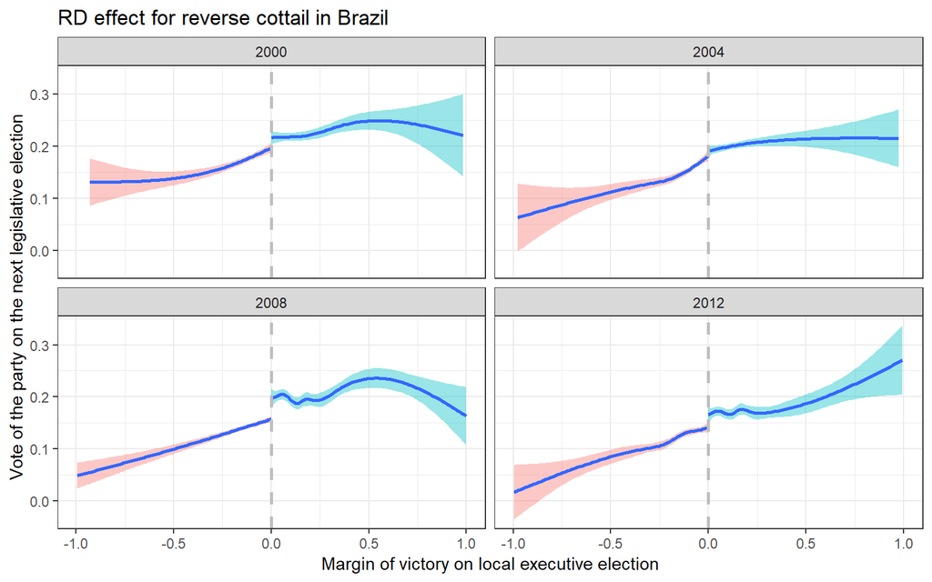

```r
ggplot(df, aes(x = vote_margin_share, y = vs_party, group = as.factor(treat),
    fill = as.factor(treat))) +
geom_smooth() +
geom_vline(aes(xintercept = 0), color = "grey", size = 1, linetype = "dashed") +

labs(x = "Margin of victory on local executive election", y = "Vote of the party on the next legislative election",
    title = "RD effect for reverse cottail in Brazil") +
theme_bw() +
facet_wrap(~ANO_ELEICAO) +
theme(legend.position = "None")
```

## Geom_errorbar

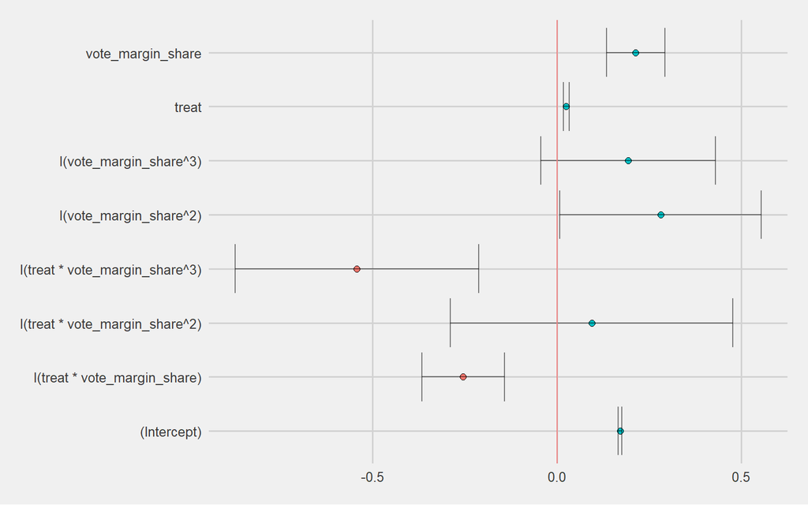

```r
library(broom)

# Model
mod.1 <- lm(vs_party ~ treat + vote_margin_share + I(vote_margin_share^2) +
    I(vote_margin_share^3) + I(treat * vote_margin_share) + I(treat * vote_margin_share^2) +
    I(treat * vote_margin_share^3), data = df)

# summary(mod.1)
result <- tidy(mod.1) %>% mutate(upper = estimate + std.error * 1.96, lower = estimate -
    std.error * 1.96, col = ifelse(estimate > 0, "Positive", "Negative"))



## Graph

ggplot(result, aes(y = estimate, x = term, fill = col)) +
geom_point(alpha = 1, shape = 21, size = 2, colour = "black") +
geom_errorbar(aes(ymax = upper, ymin = lower), colour = "black", fill = "black",
    alpha = 0.5) +
ylab("Estimates") +
geom_hline(aes(yintercept = 0), color = "lightcoral") +
coord_flip() +
xlab("") +
ggthemes::theme_fivethirtyeight() +
theme(legend.position = "None")
```

## geom_col

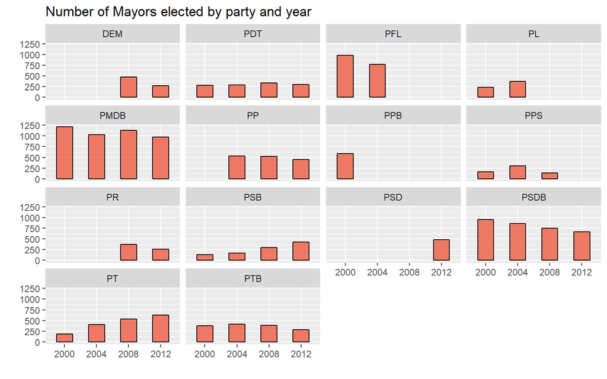

```r
conflict_prefer("filter", "dplyr")

d_top10 <- df %>%
filter(treat == 1) %>%
group_by(ANO_ELEICAO, SIGLA_PARTIDO.x) %>%
summarise(mayor = n()) %>%
top_n(10)


ggplot(d_top10, aes(x = as.factor(ANO_ELEICAO), y = mayor)) +
geom_col(fill = "tomato2", alpha = 0.8, color = "black", width = 0.5) +
labs(title = "Number of Mayors elected by party and year", y = "", x = "") +

facet_wrap(~SIGLA_PARTIDO.x)
```

## Multiple Layers

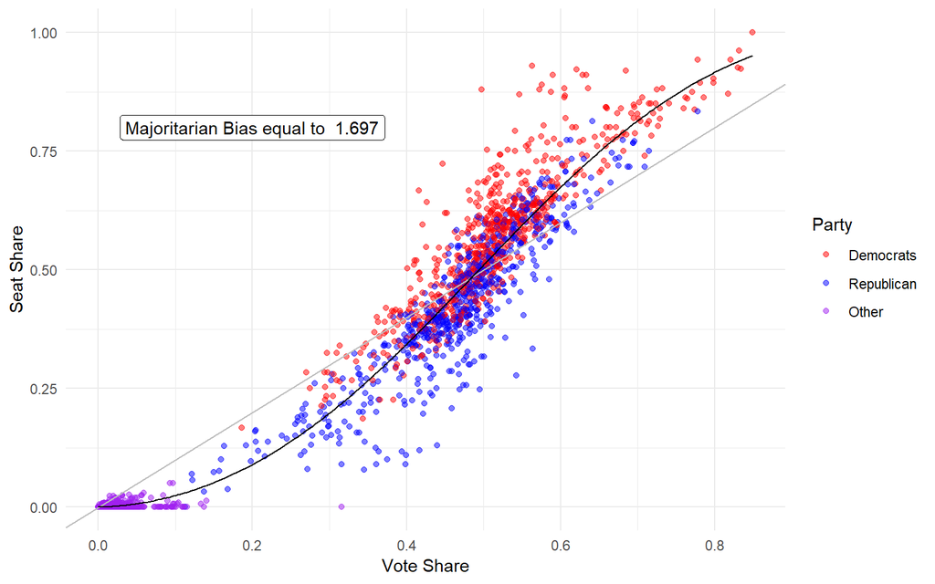

```r
load("seats_votes.Rdata")

ggplot(us_data, aes(y = seatshare, x = v)) +
geom_point(aes(color = party), alpha = 0.5) +

geom_abline(color = "gray") +
ylab("Seat Share") + xlab("Vote Share") +
geom_line(data = cen, aes(y = cen$p, x = v), color = "black") +
scale_color_manual(values = c("red", "blue", "purple"), labels = c("Democrats",
    "Republican", "Other"), name = "Party") + theme_minimal() +
annotate("label", label = paste("Majoritarian Bias equal to ", round(my.coef[1],
    digits = 3)), y = 0.8, x = 0.2)
```

Tiago Ventura

2019-12-09